# Income and Wildfire Risk Analysis

Jiayuan Jiang

2025-11-03

###Introduction

This report analyzes the relationship between household income and wildfire risk across California census block groups. The goal is to understand whether income level is associated with fire hazard exposure, and how this relationship varies spatially.

We use a dataset that combines

- Median household income from the *American Community Survey (ACS 2022)*
- Fire Hazard Severity Zones from *CAL FIRE*

###Data Preparation

```r
pacman::p_load(
  sf,           # Spatial data processing
  ggplot2,      # Plotting
  dplyr,        # Data processing
  scales,       # Scales and formatting
  viridis,      # Color mapping
  ggspatial,    # Add compass and scale bar
  RColorBrewer, # Color schemes
  classInt,     # Classification intervals
  readr,
  scales,
  tmap
)
# Set working directory (adjust to your path)

setwd("/Users/avalanchy/Downloads/EAS548-648-Geovisiual/lab02")

# Read and clean data

data <- read_csv("census_fire_analysis/census_fire_risk_data.csv", show_col_types = FALSE) %>%
filter(!is.na(income_clean),!is.na(fire_risk_level),income_clean > 0,!is.na(income_quantile_label)) %>%
mutate(fire_risk_category = factor(fire_risk_level,levels = 0:3,labels = c("No Risk", "Low Risk", "Moderate Risk", "High Risk")),income_quantile_ordered =factor(income_quantile_label,levels = c("Lowest 20%", "Low 20%", "Middle 20%", "High 20%", "Highest 20%")),income_k = income_clean / 1000)

summary(data)
```

```
##   income_clean    income_quantile_num income_quantile_label fire_risk_level
##  Min.   :  2499   Min.   :1           Length:24010          Min.   :0.000
##  1st Qu.: 66460   1st Qu.:2           Class :character      1st Qu.:0.000
##  Median : 94044   Median :3           Mode  :character      Median :0.000
##  Mean   :104957   Mean   :3                                 Mean   :1.074
##  3rd Qu.:131964   3rd Qu.:4                                 3rd Qu.:3.000
##  Max.   :250001   Max.   :5                                 Max.   :3.000
##  fire_risk_label    income_formatted   risk_category       fire_risk_category
##  Length:24010       Length:24010       Min.   :0.000   No Risk      :14889
##  Class :character   Class :character   1st Qu.:0.000   Low Risk     :  359
##  Mode  :character   Mode  :character   Median :0.000   Moderate Risk:  858
##                                        Mean   :1.074   High Risk    : 7904
##                                        3rd Qu.:3.000
##                                        Max.   :3.000
##  income_quantile_ordered    income_k
##  Lowest 20% :4802        Min.   :  2.499
##  Low 20%    :4802        1st Qu.: 66.460
##  Middle 20% :4802        Median : 94.043
##  High 20%   :4802        Mean   :104.957
##  Highest 20%:4802        3rd Qu.:131.964
##                          Max.   :250.001
```

We clean the dataset by removing missing or invalid values and create two main variables

-`income_quantile_ordered`: categorical income quintiles

-`fire_risk_category`: four fire risk levels (No, Low, Moderate, High)

### Geovisualization: Fire Risk Map

```r
setwd("/Users/avalanchy/Downloads")

census_file <- "/Users/avalanchy/Downloads/MedianIncome.geojson"
fire_risk_file <- "/Users/avalanchy/Downloads/EAS548-648-Geovisiual/lab02/census_with_fire_risk.geojson"
map_title <- "California Census Income and Fire Risk Analysis"
map_subtitle <- "Household Income Distribution by Quantiles with Fire Hazard Zones"
map_credit <- "Data Source: U.S. Census Bureau ACS 2022 5-Year Estimates & CA FHSZ | Author: Jiayuan Jiang | Date: Nov 2025"

# Read data files
cat("Reading data files...\n")
```

```
## Reading data files...
```

```r
census_data <- st_read(census_file, quiet = TRUE)
fire_risk_data <- st_read(fire_risk_file, quiet = TRUE)

cat(sprintf("Census data: %d records\n", nrow(census_data)))
```

```
## Census data: 25607 records
```

```r
cat(sprintf("Fire risk data: %d records\n", nrow(fire_risk_data)))
```

```
## Fire risk data: 25607 records
```

```r
# Get income field name
income_field <- names(census_data)[[52]]  # Adjust index if needed
cat(sprintf("Using income field: %s\n", income_field))
```

```
## Using income field: ACS_2022_5YR_BG_06_CALIFORNIA...X19_INCOME_B19013_E001
```

```r
# Process census income data
cat("Preprocessing data...\n")
```

```
## Preprocessing data...
```

```r
census_clean <- census_data %>%
  mutate(
    income = as.numeric(.data[[income_field]]),
    income_clean = ifelse(income < 0 | is.na(income), NA, income)
  ) %>%
  filter(!is.na(income_clean))

cat(sprintf("Cleaned Census data: %d records\n", nrow(census_clean)))
```

```
## Cleaned Census data: 24010 records
```

```r
# Income data quantile classification
quantile_breaks <- quantile(census_clean$income_clean,
                            probs = c(0, 0.2, 0.4, 0.6, 0.8, 1.0),
                            na.rm = TRUE)

census_clean <- census_clean %>%
  mutate(
    income_quantile = cut(income_clean,
                          breaks = quantile_breaks,
                          include.lowest = TRUE,
                          labels = c("Lowest 20%", "Low 20%", "Middle 20%", "High 20%", "Highest 20%"))
  )

# Process fire risk data
fire_risk_clean <- fire_risk_data %>%
  filter(fire_risk_level > 0) %>%  # Only show areas with fire risk
  mutate(
    fire_risk_factor = factor(fire_risk_level,
                              levels = 1:3,
                              labels = c("Low Risk", "Moderate Risk", "High Risk"))
  )

cat(sprintf("Areas with fire risk: %d records\n", nrow(fire_risk_clean)))
```

```
## Areas with fire risk: 5395 records
```

```r
# Calculate centroids for point display
fire_risk_centroids <- fire_risk_clean %>%
  st_centroid() %>%
  mutate(
    point_size = case_when(
      fire_risk_level == 1 ~ 0.3,
      fire_risk_level == 2 ~ 1.3,
      fire_risk_level == 3 ~ 2.0
    )
  )
```

```r
# Ensure coordinate systems are consistent
if (st_crs(census_clean) != st_crs(fire_risk_centroids)) {
  fire_risk_centroids <- st_transform(fire_risk_centroids, st_crs(census_clean))
}

# Create map
cat("Creating map...\n")
```

```
## Creating map...
```

```r
# Define color schemes
income_colors <- brewer.pal(5, "Blues")  # Blue gradient for income
fire_colors <- c("Low Risk" = "#FED976", "Moderate Risk" = "#FD8D3C", "High Risk" = "#E31A1C")  # Yellow to red for fire risk

# Calculate map boundaries
bbox <- st_bbox(census_clean)

# Create ggplot map
p <- ggplot() +
  # Bottom layer: Census income data (polygons)
  geom_sf(data = census_clean,
          aes(fill = income_quantile),
          color = "white",
          size = 0.05,
          alpha = 0.8) +

  # Top layer: Fire risk data (points)
  geom_sf(data = fire_risk_centroids,
          aes(color = fire_risk_factor,
              size = fire_risk_factor),
          alpha = 0.5,
          stroke = 0.3) +

  # Income color mapping
  scale_fill_manual(
    name = "Household Income\nQuantiles",
    values = income_colors,
    na.value = "grey95"
  ) +

  # Fire risk color and size mapping
  scale_color_manual(
    name = "Fire Risk Level",
    values = fire_colors
  ) +

  scale_size_manual(
    name = "Fire Risk Level",
    values = c("Low Risk" = 0.8, "Moderate Risk" = 1.5, "High Risk" = 2.5)
  ) +

  # Add scale bar
  ggspatial::annotation_scale(
    location = "bl",
    unit_category = "metric",
    text_family = "Arial",
    text_col = "grey30",
    bar_cols = c("grey60", "white"),
    line_width = 1,
    height = unit(0.3, "cm"),
    text_cex = 0.8
  ) +

  # Add north arrow
  ggspatial::annotation_north_arrow(
    location = "tr",
    which_north = "true",
    pad_x = unit(0.2, "cm"),
    pad_y = unit(0.2, "cm"),
    style = ggspatial::north_arrow_fancy_orienteering(
      fill = c("grey60", "white"),
      line_col = "grey30",
      text_col = "grey30"
    ),
    height = unit(1.5, "cm"),
    width = unit(1.5, "cm")
  ) +

  # Add title and subtitle at the top
  labs(
    title = map_title,
    subtitle = '',
    caption = map_credit
  ) +

  # Map styling
  theme_void() +
  theme(
    legend.position = "right",
    legend.box = "vertical",
    legend.spacing.y = unit(0.5, "cm"),
    legend.margin = margin(l = 20),
    legend.title = element_text(size = 14, face = "bold"),  # Larger legend font
    legend.text = element_text(size = 12),                  # Larger legend font
    legend.key.size = unit(0.8, "cm"),
    panel.background = element_rect(fill = "white", color = NA),
    plot.background = element_rect(fill = "white", color = NA),

    # ========== ==========
    plot.title = element_text(
      size = 18,
      face = "bold",
      hjust = 0.5,
      vjust = 2,
      margin = margin(t = 2, b = 5)
    ),
    plot.subtitle = element_text(
      size = 13,
      hjust = 0.5,
      vjust = 1,
      color = "grey30",
      margin = margin(b = 15)
    ),

    plot.caption = element_text(
      size = 10,
      hjust = 0.5,
      vjust = -1,
      color = "grey50",
      margin = margin(t = 15)
    ),

    plot.margin = margin(15, 10, 15, 10)
  ) +

  # Coordinate system
  coord_sf(
    xlim = c(bbox[1], bbox[3]),
    ylim = c(bbox[2], bbox[4]),
    expand = FALSE
  )

# Display map
cat("Displaying map...\n")
```

```
## Displaying map...
```

```r
print(p)
```

```
## Scale on map varies by more than 10%, scale bar may be inaccurate
```

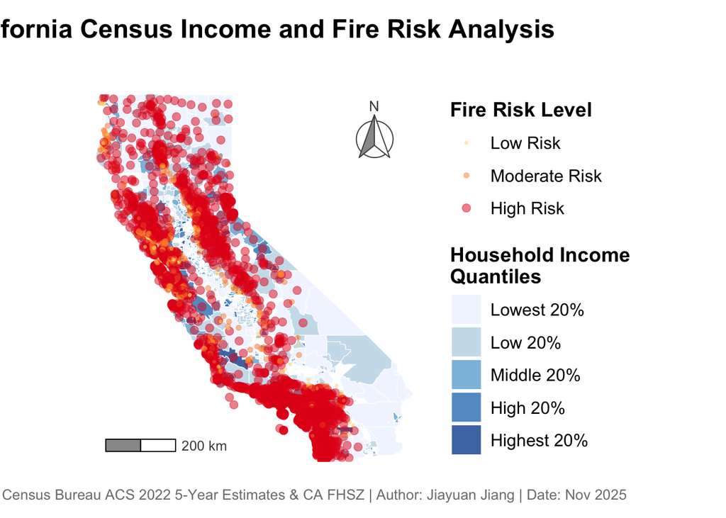

***

This map shows the *spatial pattern* of fire risk across California. Areas in darker red represent higher fire hazard zones. Combining this with income data helps visualize whether wealthier regions overlap with higher-risk areas.

### Statistical Relationship: Income vs Fire Risk

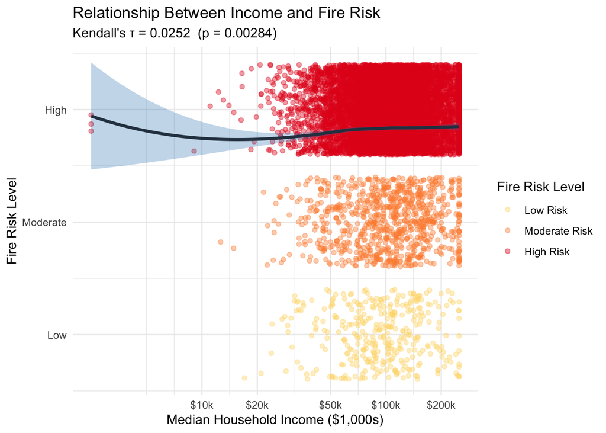

```r
# Scatter plot with loess trend line

data_filtered <- data %>%
filter(fire_risk_level > 0)

kendall_result <- cor.test(data_filtered$income_clean, data_filtered$fire_risk_level, method = "kendall")
tau_value <- round(as.numeric(kendall_result$estimate), 4)

p <- ggplot(data_filtered, aes(x = income_k, y = fire_risk_level)) +
geom_jitter(aes(color = fire_risk_category), alpha = 0.4, size = 1.5) +
geom_smooth(method = "loess", se = TRUE, color = "#2c3e50", fill = "#3182BD", linewidth = 1.2, alpha = 0.3) +
scale_color_manual(
name = "Fire Risk Level",
values = c("Low Risk" = "#FED976", "Moderate Risk" = "#FD8D3C", "High Risk" = "#E31A1C")
) +
scale_x_log10(
name = "Median Household Income ($1,000s)",
breaks = c(10, 20, 50, 100, 200, 500),
labels = function(x) paste0("$", x, "k")
) +
scale_y_continuous(
name = "Fire Risk Level",
breaks = 1:3,
labels = c("Low", "Moderate", "High")
) +
theme_minimal() +
labs(
title = "Relationship Between Income and Fire Risk",
subtitle = paste0("Kendall's τ = ", tau_value, "  (p = ", signif(kendall_result$p.value, 3), ")")
)

p
```

We use Kendall’s Tau correlation test to quantify the monotonic relationship between income and fire risk.

- *Kendall’s τ* = 0.0252
- A small positive value suggests that higher income areas tend to have *slightly higher* fire risk exposure, likely due to development patterns in suburban–wildland interface zones.

### Distribution Across Income Groups

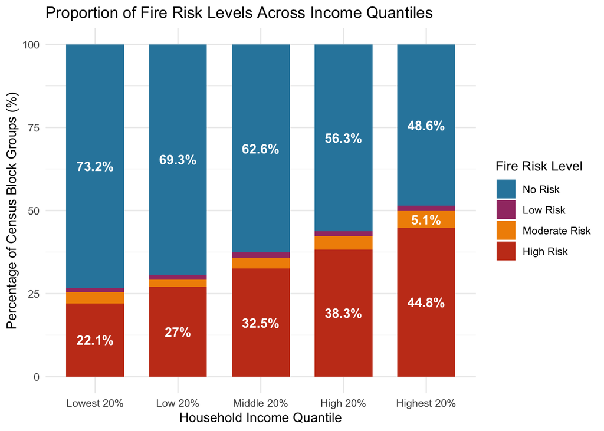

```r
plot_data <- data %>%
group_by(income_quantile_ordered, fire_risk_category) %>%
summarise(count = n(), .groups = "drop") %>%
group_by(income_quantile_ordered) %>%
mutate(
total = sum(count),
proportion = count / total,
percentage = proportion * 100
)

ggplot(plot_data, aes(x = income_quantile_ordered, y = percentage, fill = fire_risk_category)) +
geom_col(position = "stack", width = 0.7) +
geom_text(
aes(label = ifelse(percentage > 5, paste0(round(percentage, 1), "%"), "")),
position = position_stack(vjust = 0.5),
color = "white",
fontface = "bold"
) +
scale_fill_manual(
name = "Fire Risk Level",
values = c(
"No Risk" = "#2E86AB",
"Low Risk" = "#A23B72",
"Moderate Risk" = "#F18F01",
"High Risk" = "#C73E1D"
)
) +
labs(
title = "Proportion of Fire Risk Levels Across Income Quantiles",
x = "Household Income Quantile",
y = "Percentage of Census Block Groups (%)"
) +
theme_minimal()
```

- Wealthier households are often located in suburban areas near wildland–urban interfaces (WUI), where fire hazards are greater.
- Lower-income communities, more concentrated in urban centers, face lower wildfire exposure.

This aligns with findings from previous studies that *environmental risk is not always inversely related to income*; some hazards disproportionately affect affluent regions due to land-use choices.

### Conclusion

Conclusion

This project demonstrates how combining *statistical analysis* and *geospatial visualization* can uncover nuanced patterns between *socioeconomic status* and *environmental risk*.